Yongsang Park

## 1. Skin wounds

```r
SRS = c(29, 27, 34, 40, 22, 28, 14, 35, 26, 35, 12, 30, 23, 18, 11, 22, 23, 33)
n = 18
```

## 1a.

If you create a qq plot,

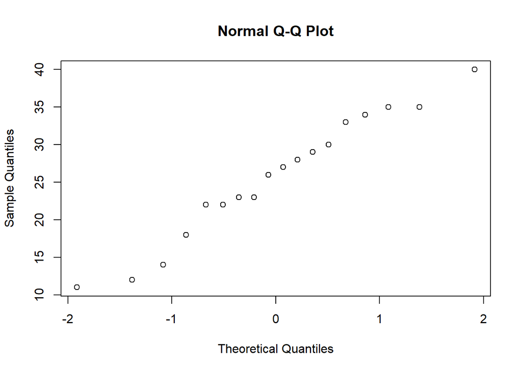

```r
qqnorm(SRS)
```

It is a little bit concave down but allowable. So I will say the population distribution is normal.

## 1b.

The test mean is

```r
meanSRS = mean(SRS)
meanSRS
```

```
## [1] 25.66667
```

and test SD is

```r
sdSRS = sd(SRS)
sdSRS
```

```
## [1] 8.324309
```

and alpha = 0.9. We want to know CI for the mean with alpha = 0.9

```r
interval = -qt(0.05, n - 1) * sdSRS / sqrt(n)
interval
```

```
## [1] 3.41321
```

```r
left = meanSRS - interval
left
```

```
## [1] 22.25346
```

```r
right = meanSRS + interval
right
```

```
## [1] 29.07988
```

so the interval is 22.25346 < mu < 29.07988

## 1c.

H0: mu = 25, HA: mu != 25

and our interval includes 25 in significant level of 0.10, so we do not reject H0.

## 1d.

Is this the strong evidence that the population mean rate is significantly greater than 25 at level alpha=0.05?

```r
Tstat = (meanSRS - 25) / (sdSRS / sqrt(n))
pVal = 1 - pt(Tstat, n - 1)
pVal
```

```
## [1] 0.3690923
```

and it is beyond 0.05, so this does not abort the null hypothesis that the population mean rate is greater than 25 at level alpha-0.05.

## 1e.

If the standard deviation of population is given, it means the question will be changed from t test to normal distribution problem. So the answer will be 2, 4.

## 2. Test and power

```r
n = 10
```

H_0: mu = 12 vs. H_A: mu != 12

```r
alpha = 0.1
sampleMean = 14.2
sampleSD = 4.88
```

## 2a.

The test statistic, T is

```r
Tstat = (sampleMean - 12) / (sampleSD / sqrt(n))
Tstat
```

```
## [1] 1.425617
```

and the p value of this is

```r
pVal = 1 - pt(q = Tstat, df = n - 1) + pt(q= -Tstat, df = n - 1)
pVal
```

```
## [1] 0.187726
```

This value is beyond alpha = 0.1, so we do not reject the null hypothesis.

## 2b.

The confidence interval is

```r
interval = qt(p = 1 - alpha / 2, df = n - 1) * sampleSD / sqrt(n)
```

from

```r
left = sampleMean - interval
left
```

```
## [1] 11.37116
```

to

```r
right = sampleMean + interval
right
```

```
## [1] 17.02884
```

and it includes 12. So I can tell a 90% confidence interval includes 12.

## 2c.

The quantile of alpha in the true population is

```r
mu = 15
left = mu + qnorm(alpha / 2) * sampleSD / sqrt(n)
left
```

```
## [1] 12.46168
```

```r
right = mu + qnorm(1 - alpha / 2) * sampleSD / sqrt(n)
right
```

```
## [1] 17.53832
```

And we need to reject X.bar < 12.46168 and X.bar > 17.53832

```r
pnorm(q = left, mean = 12, sd = sampleSD) + 1 - pnorm(q = right, mean = 12, sd = sampleSD)
```

```
## [1] 0.6658941
```

The power is 0.6658941